# Credit Card Fraud Detection

## Credit Card Fraud Detection

The datasets contains transactions made by credit cards in September 2013 by european cardholders. This dataset presents transactions that occurred in two days, where we have 492 frauds out of 284,807 transactions. The dataset is highly unbalanced, the positive class (frauds) account for 0.172% of all transactions.

It contains only numerical input variables which are the result of a PCA transformation. Unfortunately, due to confidentiality issues, we cannot provide the original features and more background information about the data. Features V1, V2, ... V28 are the principal components obtained with PCA, the only features which have not been transformed with PCA are 'Time' and 'Amount'. Feature 'Time' contains the seconds elapsed between each transaction and the first transaction in the dataset. The feature 'Amount' is the transaction Amount, this feature can be used for example-dependant cost-senstive learning. Feature 'Class' is the response variable and it takes value 1 in case of fraud and 0 otherwise.

kaggle dataset url: https://www.kaggle.com/mlg-ulb/creditcardfraud

## Import necessary libraries

```python
#Importing Data manipulation and plotting modules
import numpy as np
import pandas as pd
import matplotlib.pyplot as plt
import seaborn as sns
import os
import time
%matplotlib inline
```

```python
#Importing libraries for performance measures
from sklearn.metrics import confusion_matrix
from sklearn.metrics import precision_recall_fscore_support
from sklearn.metrics import accuracy_score
from sklearn.metrics import auc, roc_curve
```

```python
#Importing libraries For data splitting
from sklearn.model_selection import train_test_split
from xgboost.sklearn import XGBClassifier
from sklearn.ensemble import RandomForestClassifier
```

```python
#Import libraries for data balancing
from imblearn.over_sampling import SMOTE
```

```python
data = pd.read_csv("creditcard.csv")
```

```python
data.shape
```

```
(284807, 31)
```

```python
data.head()
```

|  | Time | V1 | V2 | V3 | V4 | V5 | V6 | V7 | V8 | V9 | ... | V21 | V22 | V23 | V24 | V25 | V26 | V27 | V28 | Amount | Class |
| --- | --- | --- | --- | --- | --- | --- | --- | --- | --- | --- | --- | --- | --- | --- | --- | --- | --- | --- | --- | --- | --- |
| 0 | 0.0 | -1.359807 | -0.072781 | 2.536347 | 1.378155 | -0.338321 | 0.462388 | 0.239599 | 0.098698 | 0.363787 | ... | -0.018307 | 0.277838 | -0.110474 | 0.066928 | 0.128539 | -0.189115 | 0.133558 | -0.021053 | 149.62 | 0 |
| 1 | 0.0 | 1.191857 | 0.266151 | 0.166480 | 0.448154 | 0.060018 | -0.082361 | -0.078803 | 0.085102 | -0.255425 | ... | -0.225775 | -0.638672 | 0.101288 | -0.339846 | 0.167170 | 0.125895 | -0.008983 | 0.014724 | 2.69 | 0 |
| 2 | 1.0 | -1.358354 | -1.340163 | 1.773209 | 0.379780 | -0.503198 | 1.800499 | 0.791461 | 0.247676 | -1.514654 | ... | 0.247998 | 0.771679 | 0.909412 | -0.689281 | -0.327642 | -0.139097 | -0.055353 | -0.059752 | 378.66 | 0 |
| 3 | 1.0 | -0.966272 | -0.185226 | 1.792993 | -0.863291 | -0.010309 | 1.247203 | 0.237609 | 0.377436 | -1.387024 | ... | -0.108300 | 0.005274 | -0.190321 | -1.175575 | 0.647376 | -0.221929 | 0.062723 | 0.061458 | 123.50 | 0 |
| 4 | 2.0 | -1.158233 | 0.877737 | 1.548718 | 0.403034 | -0.407193 | 0.095921 | 0.592941 | -0.270533 | 0.817739 | ... | -0.009431 | 0.798278 | -0.137458 | 0.141267 | -0.206010 | 0.502292 | 0.219422 | 0.215153 | 69.99 | 0 |

5 rows × 31 columns

```python
pd.options.display.max_columns = 200
```

```python
data.head()
```

|  | Time | V1 | V2 | V3 | V4 | V5 | V6 | V7 | V8 | V9 | V10 | V11 | V12 | V13 | V14 | V15 | V16 | V17 | V18 | V19 | V20 | V21 | V22 | V23 | V24 | V25 | V26 | V27 | V28 | … |
| --- | --- | --- | --- | --- | --- | --- | --- | --- | --- | --- | --- | --- | --- | --- | --- | --- | --- | --- | --- | --- | --- | --- | --- | --- | --- | --- | --- | --- | --- | --- |
| 0 | 0.0 | -1.359807 | -0.072781 | 2.536347 | 1.378155 | -0.338321 | 0.462388 | 0.239599 | 0.098698 | 0.363787 | 0.090794 | -0.551600 | -0.617801 | -0.991390 | -0.311169 | 1.468177 | -0.470401 | 0.207971 | 0.025791 | 0.403993 | 0.251412 | -0.018307 | 0.277838 | -0.110474 | 0.066928 | 0.128539 | -0.189115 | 0.133558 | -0.021053 | … |
| 1 | 0.0 | 1.191857 | 0.266151 | 0.166480 | 0.448154 | 0.060018 | -0.082361 | -0.078803 | 0.085102 | -0.255425 | -0.166974 | 1.612727 | 1.065235 | 0.489095 | -0.143772 | 0.635558 | 0.463917 | -0.114805 | -0.183361 | -0.145783 | -0.069083 | -0.225775 | -0.638672 | 0.101288 | -0.339846 | 0.167170 | 0.125895 | -0.008983 | 0.014724 | … |
| 2 | 1.0 | -1.358354 | -1.340163 | 1.773209 | 0.379780 | -0.503198 | 1.800499 | 0.791461 | 0.247676 | -1.514654 | 0.207643 | 0.624501 | 0.066084 | 0.717293 | -0.165946 | 2.345865 | -2.890083 | 1.109969 | -0.121359 | -2.261857 | 0.524980 | 0.247998 | 0.771679 | 0.909412 | -0.689281 | -0.327642 | -0.139097 | -0.055353 | -0.059752 | … |
| 3 | 1.0 | -0.966272 | -0.185226 | 1.792993 | -0.863291 | -0.010309 | 1.247203 | 0.237609 | 0.377436 | -1.387024 | -0.054952 | -0.226487 | 0.178228 | 0.507757 | -0.287924 | -0.631418 | -1.059647 | -0.684093 | 1.965775 | -1.232622 | -0.208038 | -0.108300 | 0.005274 | -0.190321 | -1.175575 | 0.647376 | -0.221929 | 0.062723 | 0.061458 | … |
| 4 | 2.0 | -1.158233 | 0.877737 | 1.548718 | 0.403034 | -0.407193 | 0.095921 | 0.592941 | -0.270533 | 0.817739 | 0.753074 | -0.822843 | 0.538196 | 1.345852 | -1.119670 | 0.175121 | -0.451449 | -0.237033 | -0.038195 | 0.803487 | 0.408542 | -0.009431 | 0.798278 | -0.137458 | 0.141267 | -0.206010 | 0.502292 | 0.219422 | 0.215153 | … |

```python
def DescriptiveStatistics(df):
    print("No of rwos and columns information:",df.shape)
    print("")
    print("---"*20)
    print("")
    print("Columns:")
    print("")
    print(df.columns.values)
    print("---"*20)
    print("")
    print(df.info())
    print("---"*20)
    print("")
    print(df.describe())
```

```python
DescriptiveStatistics(data)
```

```
No of rwos and columns information: (284807, 31)

------------------------------------------------------------

Columns:

['Time' 'V1' 'V2' 'V3' 'V4' 'V5' 'V6' 'V7' 'V8' 'V9' 'V10' 'V11' 'V12'
 'V13' 'V14' 'V15' 'V16' 'V17' 'V18' 'V19' 'V20' 'V21' 'V22' 'V23' 'V24'
 'V25' 'V26' 'V27' 'V28' 'Amount' 'Class']
------------------------------------------------------------

<class 'pandas.core.frame.DataFrame'>
RangeIndex: 284807 entries, 0 to 284806
Data columns (total 31 columns):
Time      284807 non-null float64
V1        284807 non-null float64
V2        284807 non-null float64
V3        284807 non-null float64
V4        284807 non-null float64
V5        284807 non-null float64
V6        284807 non-null float64
V7        284807 non-null float64
V8        284807 non-null float64
V9        284807 non-null float64
V10       284807 non-null float64
V11       284807 non-null float64
V12       284807 non-null float64
V13       284807 non-null float64
V14       284807 non-null float64
V15       284807 non-null float64
V16       284807 non-null float64
V17       284807 non-null float64
V18       284807 non-null float64
V19       284807 non-null float64
V20       284807 non-null float64
V21       284807 non-null float64
V22       284807 non-null float64
V23       284807 non-null float64
V24       284807 non-null float64
V25       284807 non-null float64
```

[output cut: 64 more lines]

```
min   -1.029540e+01 -2.604551e+00 -2.256568e+01 -1.543008e+01       0.000000
25%   -3.171451e-01 -3.269839e-01 -7.083953e-02 -5.295979e-02       5.600000
50%    1.659350e-02 -5.213911e-02  1.342146e-03  1.124383e-02      22.000000
75%    3.507156e-01  2.409522e-01  9.104512e-02  7.827995e-02      77.165000
max    7.519589e+00  3.517346e+00  3.161220e+01  3.384781e+01   25691.160000

               Class
count  284807.000000
mean        0.001727
std         0.041527
min         0.000000
25%         0.000000
50%         0.000000
75%         0.000000
max         1.000000
```

```python
def CheckMissingInfo(df):
    print(df.isnull().sum())
    print("---"*20)
    print("")
    df_na = (df.isnull().sum() / len(df)) * 100
    df_na = df_na.drop(df_na[df_na == 0].index).sort_values(ascending=False)[:30]
    missing_data = pd.DataFrame({'Missing Ratio' :df_na})
    print(missing_data)
```

```python
CheckMissingInfo(data)
```

```
Time      0
V1        0
V2        0
V3        0
V4        0
V5        0
V6        0
V7        0
V8        0
V9        0
V10       0
V11       0
V12       0
V13       0
V14       0
V15       0
V16       0
V17       0
V18       0
V19       0
V20       0
V21       0
V22       0
V23       0
V24       0
V25       0
V26       0
V27       0
V28       0
Amount    0
Class     0
dtype: int64
------------------------------------------------------------

Empty DataFrame
Columns: [Missing Ratio]
Index: []
```

```python
def GetColumnCount(df):
    int_columns = [col for col in df.columns if(df[col].dtype != "object")]
    print("No of integer type columns:",len(int_columns))
    print(int_columns)
    print("")
    obj_columns = [col for col in df.columns if(df[col].dtype == "object")]
    print("No of object type columns:",len(obj_columns))
    print(obj_columns)
    return int_columns,obj_columns
```

```python
int_columns,obj_columns = GetColumnCount(data)
```

```
No of integer type columns: 31
['Time', 'V1', 'V2', 'V3', 'V4', 'V5', 'V6', 'V7', 'V8', 'V9', 'V10', 'V11', 'V12', 'V13', 'V14', 'V15', 'V16', 'V17', 'V18', 'V19', 'V20', 'V21', 'V22', 'V23', 'V24', 'V25', 'V26', 'V27', 'V28', 'Amount', 'Class']

No of object type columns: 0
[]
```

```python
def GetCountPlots(df,obj_columns):
    for col in obj_columns:
        if(len(df[col].value_counts()) < 5):
            plt.figure(figsize=(5,5))
        else:
            plt.figure(figsize=(12,6))
        print(sns.countplot(x=col, data=df, palette="muted"))
        plt.show()
```

```
AxesSubplot(0.125,0.125;0.775x0.755)
```

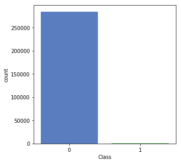

```python
GetCountPlots(data,['Class'])
```

```python
data.Class.value_counts(normalize=True)
```

```
0    0.998273
1    0.001727
Name: Class, dtype: float64
```

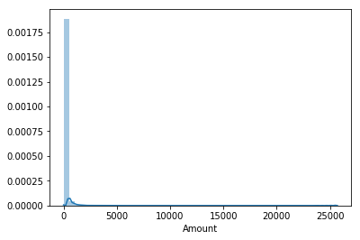

```python
sns.distplot(data['Amount'])
```

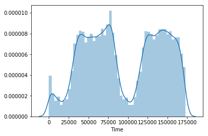

```python
sns.distplot(data['Time'])
```

```python
data.drop(['Time'], inplace = True, axis =1)

from sklearn.preprocessing import StandardScaler
data['Amount'] = StandardScaler().fit_transform(data['Amount'].values.reshape(-1,1))
#data = data.drop(['Amount'],axis=1)
```

```python
data.head()
#data.shape
```

|  | V1 | V2 | V3 | V4 | V5 | V6 | V7 | V8 | V9 | V10 | V11 | V12 | V13 | V14 | V15 | V16 | V17 | V18 | V19 | V20 | V21 | V22 | V23 | V24 | V25 | V26 | V27 | V28 | Amount | … |
| --- | --- | --- | --- | --- | --- | --- | --- | --- | --- | --- | --- | --- | --- | --- | --- | --- | --- | --- | --- | --- | --- | --- | --- | --- | --- | --- | --- | --- | --- | --- |
| 0 | -1.359807 | -0.072781 | 2.536347 | 1.378155 | -0.338321 | 0.462388 | 0.239599 | 0.098698 | 0.363787 | 0.090794 | -0.551600 | -0.617801 | -0.991390 | -0.311169 | 1.468177 | -0.470401 | 0.207971 | 0.025791 | 0.403993 | 0.251412 | -0.018307 | 0.277838 | -0.110474 | 0.066928 | 0.128539 | -0.189115 | 0.133558 | -0.021053 | 0.244964 | … |
| 1 | 1.191857 | 0.266151 | 0.166480 | 0.448154 | 0.060018 | -0.082361 | -0.078803 | 0.085102 | -0.255425 | -0.166974 | 1.612727 | 1.065235 | 0.489095 | -0.143772 | 0.635558 | 0.463917 | -0.114805 | -0.183361 | -0.145783 | -0.069083 | -0.225775 | -0.638672 | 0.101288 | -0.339846 | 0.167170 | 0.125895 | -0.008983 | 0.014724 | -0.342475 | … |
| 2 | -1.358354 | -1.340163 | 1.773209 | 0.379780 | -0.503198 | 1.800499 | 0.791461 | 0.247676 | -1.514654 | 0.207643 | 0.624501 | 0.066084 | 0.717293 | -0.165946 | 2.345865 | -2.890083 | 1.109969 | -0.121359 | -2.261857 | 0.524980 | 0.247998 | 0.771679 | 0.909412 | -0.689281 | -0.327642 | -0.139097 | -0.055353 | -0.059752 | 1.160686 | … |
| 3 | -0.966272 | -0.185226 | 1.792993 | -0.863291 | -0.010309 | 1.247203 | 0.237609 | 0.377436 | -1.387024 | -0.054952 | -0.226487 | 0.178228 | 0.507757 | -0.287924 | -0.631418 | -1.059647 | -0.684093 | 1.965775 | -1.232622 | -0.208038 | -0.108300 | 0.005274 | -0.190321 | -1.175575 | 0.647376 | -0.221929 | 0.062723 | 0.061458 | 0.140534 | … |
| 4 | -1.158233 | 0.877737 | 1.548718 | 0.403034 | -0.407193 | 0.095921 | 0.592941 | -0.270533 | 0.817739 | 0.753074 | -0.822843 | 0.538196 | 1.345852 | -1.119670 | 0.175121 | -0.451449 | -0.237033 | -0.038195 | 0.803487 | 0.408542 | -0.009431 | 0.798278 | -0.137458 | 0.141267 | -0.206010 | 0.502292 | 0.219422 | 0.215153 | -0.073403 | … |

```python
y = data.iloc[:,29]
X = data.iloc[:,0:29]
X.shape
```

```
(284807, 29)
```

```python
X_train, X_test, y_train, y_test =   train_test_split(X,y,test_size = 0.3)
```

```python
X_train.shape, y_train.shape
```

```
((199364, 29), (199364,))
```

```python
X_test.shape, y_test.shape
```

```
((85443, 29), (85443,))
```

```python
from scipy import stats
from scipy.stats import norm, skew #for some statistics
from scipy.special import boxcox1p

import warnings
def ignore_warn(*args, **kwargs):
    pass
warnings.warn = ignore_warn #ignore annoying warning (from sklearn and seaborn)
```

Significance of confusion matrix that can be seen for this dataset -

True Positive: Number of fraud cases the model predicted as 'fraud'.

False Positive: Number of non-fraud cases that the model predicted as 'fraud'.

True Negative: Number of non-fraud cases that the model predicted as 'non-fraud'.

False Negative: Number of fraud cases that the model predicted as 'non-fraud'.

Precision: Precision is the ratio of correctly predicted fraud cases to total predicted fraud cases.

Hence we can focus on the model that gives least False Negative values.

```python
data.head()
```

|  | V1 | V2 | V3 | V4 | V5 | V6 | V7 | V8 | V9 | V10 | V11 | V12 | V13 | V14 | V15 | V16 | V17 | V18 | V19 | V20 | V21 | V22 | V23 | V24 | V25 | V26 | V27 | V28 | Amount | … |
| --- | --- | --- | --- | --- | --- | --- | --- | --- | --- | --- | --- | --- | --- | --- | --- | --- | --- | --- | --- | --- | --- | --- | --- | --- | --- | --- | --- | --- | --- | --- |
| 0 | -1.359807 | -0.072781 | 2.536347 | 1.378155 | -0.338321 | 0.462388 | 0.239599 | 0.098698 | 0.363787 | 0.090794 | -0.551600 | -0.617801 | -0.991390 | -0.311169 | 1.468177 | -0.470401 | 0.207971 | 0.025791 | 0.403993 | 0.251412 | -0.018307 | 0.277838 | -0.110474 | 0.066928 | 0.128539 | -0.189115 | 0.133558 | -0.021053 | 0.244964 | … |
| 1 | 1.191857 | 0.266151 | 0.166480 | 0.448154 | 0.060018 | -0.082361 | -0.078803 | 0.085102 | -0.255425 | -0.166974 | 1.612727 | 1.065235 | 0.489095 | -0.143772 | 0.635558 | 0.463917 | -0.114805 | -0.183361 | -0.145783 | -0.069083 | -0.225775 | -0.638672 | 0.101288 | -0.339846 | 0.167170 | 0.125895 | -0.008983 | 0.014724 | -0.342475 | … |
| 2 | -1.358354 | -1.340163 | 1.773209 | 0.379780 | -0.503198 | 1.800499 | 0.791461 | 0.247676 | -1.514654 | 0.207643 | 0.624501 | 0.066084 | 0.717293 | -0.165946 | 2.345865 | -2.890083 | 1.109969 | -0.121359 | -2.261857 | 0.524980 | 0.247998 | 0.771679 | 0.909412 | -0.689281 | -0.327642 | -0.139097 | -0.055353 | -0.059752 | 1.160686 | … |
| 3 | -0.966272 | -0.185226 | 1.792993 | -0.863291 | -0.010309 | 1.247203 | 0.237609 | 0.377436 | -1.387024 | -0.054952 | -0.226487 | 0.178228 | 0.507757 | -0.287924 | -0.631418 | -1.059647 | -0.684093 | 1.965775 | -1.232622 | -0.208038 | -0.108300 | 0.005274 | -0.190321 | -1.175575 | 0.647376 | -0.221929 | 0.062723 | 0.061458 | 0.140534 | … |
| 4 | -1.158233 | 0.877737 | 1.548718 | 0.403034 | -0.407193 | 0.095921 | 0.592941 | -0.270533 | 0.817739 | 0.753074 | -0.822843 | 0.538196 | 1.345852 | -1.119670 | 0.175121 | -0.451449 | -0.237033 | -0.038195 | 0.803487 | 0.408542 | -0.009431 | 0.798278 | -0.137458 | 0.141267 | -0.206010 | 0.502292 | 0.219422 | 0.215153 | -0.073403 | … |

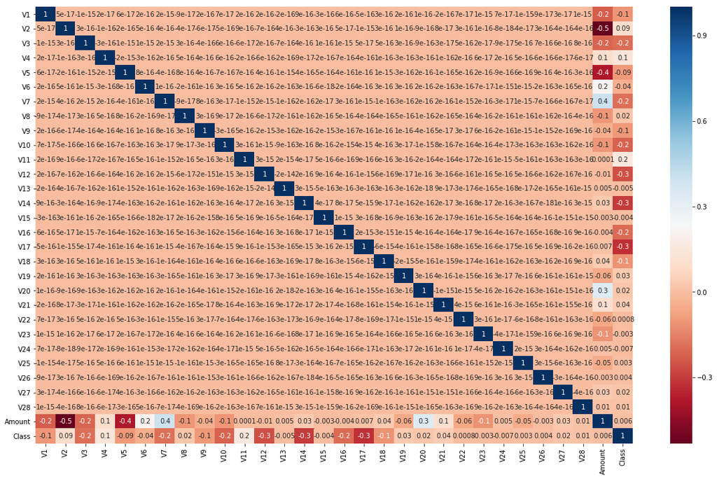

```python
plt.figure(figsize=(20,12))
sns.heatmap(data.corr(), annot=True, fmt='.1g', cmap='RdBu');
```

```python
from sklearn.metrics import make_scorer, accuracy_score,roc_auc_score,confusion_matrix, classification_report
from sklearn.model_selection import GridSearchCV
from sklearn.tree import DecisionTreeClassifier
from sklearn.ensemble import RandomForestClassifier
from sklearn.ensemble import GradientBoostingClassifier
from sklearn.model_selection import cross_val_score
```

```python
rForest = RandomForestClassifier()
grBoosting = GradientBoostingClassifier()

scores1 = cross_val_score(rForest,X_train,y_train,cv=5)
print("Accuracy for Random Forest: mean: {0:.2f} 2sd: {1:.2f}".format(scores1.mean(),scores1.std() * 2))
print("Scores::",scores1)
print("\n")

scores2 = cross_val_score(grBoosting,X_train,y_train,cv=5)
print("Accuracy for Gradient Boosting: mean: {0:.2f} 2sd: {1:.2f}".format(scores2.mean(),scores2.std() * 2))
print("Scores::",scores2)
print("\n")
```

```
Accuracy for Random Forest: mean: 1.00 2sd: 0.00
Scores:: [0.99937301 0.99947333 0.99959873 0.99954857 0.9996238 ]


Accuracy for Gradient Boosting: mean: 1.00 2sd: 0.00
Scores:: [0.99859554 0.9988965  0.99874602 0.99914729 0.99959872]
```

```python
rf = RandomForestClassifier(n_estimators=100,random_state=0, n_jobs=-1, class_weight="balanced")
```

```python
rf1 = rf.fit(X_train,y_train)
y_pred_rf = rf1.predict(X_test)
y_pred_rf_prob = rf1.predict_proba(X_test)
```

```python
accuracy_score(y_test,y_pred_rf)
```

```
0.9994733330992591
```

```python
confusion_matrix(y_test,y_pred_rf)
```

```
array([[85281,     5],
       [   40,   117]])
```

```python
p_rf,r_rf,f_rf,_  = precision_recall_fscore_support(y_test,y_pred_rf)
```

```python
print('Precision:',p_rf , '\nRecall',r_rf,'\nFscore',f_rf,_ )
```

```
Precision: [0.99953118 0.95901639]
Recall [0.99994137 0.74522293]
Fscore [0.99973624 0.83870968] [85286   157]
```

# Synthetic Minority Over sampling Technique (SMOTE)

```python
sm = SMOTE(random_state=42)
```

```python
X_smote, y_smote = sm.fit_sample(X_train, y_train)
```

```python
X_smote.shape, y_smote.shape
```

```
((398058, 29), (398058,))
```

```python
np.sum(y_smote)/len(y_smote)
```

```
0.5
```

```python
y_smote = y_smote.reshape(y_smote.size, 1)
y_smote.shape
```

```
(398058, 1)
```

```python
rf_smote = RandomForestClassifier(n_estimators=100,n_jobs=-1)
```

```python
X_train.head()
```

|  | V1 | V2 | V3 | V4 | V5 | V6 | V7 | V8 | V9 | V10 | V11 | V12 | V13 | V14 | V15 | V16 | V17 | V18 | V19 | V20 | V21 | V22 | V23 | V24 | V25 | V26 | V27 | V28 | Amount |
| --- | --- | --- | --- | --- | --- | --- | --- | --- | --- | --- | --- | --- | --- | --- | --- | --- | --- | --- | --- | --- | --- | --- | --- | --- | --- | --- | --- | --- | --- |
| 248614 | -0.054534 | 0.725503 | 0.334081 | -0.670414 | 0.449386 | -0.787455 | 0.871358 | -0.022184 | -0.267079 | -0.244435 | 0.848377 | 0.722764 | -0.378008 | 0.379383 | -1.028957 | 0.033900 | -0.555637 | -0.330287 | 0.102544 | -0.029003 | -0.193205 | -0.446315 | 0.102067 | 0.002167 | -0.550741 | 0.121486 | 0.240858 | 0.088265 | -0.313289 |
| 27952 | -0.394891 | 1.146191 | 1.669838 | 0.934066 | 0.067401 | -0.912076 | 0.875220 | -0.215165 | -0.878471 | -0.309274 | -0.086627 | 0.325585 | 0.665414 | 0.217781 | 0.971120 | -0.459228 | -0.079589 | -0.083114 | 0.344628 | 0.068139 | 0.159546 | 0.515367 | -0.221564 | 0.749326 | 0.074988 | -0.294453 | 0.130752 | 0.129341 | -0.318846 |
| 42072 | -0.551807 | 0.027683 | 2.090805 | 0.221952 | -1.430675 | 0.363913 | 0.894856 | -0.271261 | 0.636053 | -0.464364 | -0.753708 | 0.090980 | 0.064683 | -0.848600 | 0.075464 | -0.624935 | 0.369416 | -0.354443 | 1.586330 | 0.191822 | -0.175613 | -0.050680 | 0.065759 | 0.471838 | -0.628438 | 0.987728 | -0.097857 | -0.137976 | 0.511157 |
| 66026 | 1.241534 | -0.652551 | 0.618187 | -0.748399 | -1.037570 | -0.359124 | -0.701672 | 0.085478 | -1.004227 | 0.723043 | 1.868164 | 0.169861 | -0.217807 | 0.132589 | 0.352430 | 1.084347 | 0.346402 | -1.567907 | 0.462896 | 0.090201 | 0.012580 | -0.170379 | 0.150477 | 0.192606 | 0.080827 | -0.482579 | 0.015713 | 0.016249 | -0.186349 |
| 239996 | -2.644699 | -1.784427 | 0.125974 | 0.224150 | 3.819333 | -3.212980 | -0.928455 | -0.298766 | 0.021112 | -0.766687 | -0.334392 | 0.419744 | 0.901779 | -0.982547 | 0.602818 | 0.113533 | 0.313439 | 0.383604 | -0.489512 | -0.570163 | 0.159769 | 0.862691 | -0.851330 | 0.044827 | -0.024937 | -0.141054 | 0.482420 | 0.012618 | -0.299295 |

```python
columns = X_train.columns
```

```python
columns
```

```
Index(['V1', 'V2', 'V3', 'V4', 'V5', 'V6', 'V7', 'V8', 'V9', 'V10', 'V11',
       'V12', 'V13', 'V14', 'V15', 'V16', 'V17', 'V18', 'V19', 'V20', 'V21',
       'V22', 'V23', 'V24', 'V25', 'V26', 'V27', 'V28', 'Amount'],
      dtype='object')
```

```python
rf_fit = rf_smote.fit(X_smote,y_smote)
```

```python
y_pred_rfb = rf_fit.predict(X_test)
```

```python
y_pred_rfb_prob = rf_fit.predict_proba(X_test)
```

```python
p_rfb,r_rfb,f_rfb,_  = precision_recall_fscore_support(y_test,y_pred_rfb)
```

```python
print('Random Forest:\n')
print('Accuracy - ',accuracy_score(y_test,y_pred_rfb))
print('\nPrecision - ',p_rfb , '\nRecall - ',r_rfb,'\nFscore - ',f_rfb,_ )
print('Confusion Matrix -\n',confusion_matrix(y_test,y_pred_rfb))
```

```
Random Forest:

Accuracy -  0.9995084442259752

Precision -  [0.99962489 0.92592593]
Recall -  [0.99988275 0.79617834]
Fscore -  [0.9997538  0.85616438] [85286   157]
Confusion Matrix -
 [[85276    10]
 [   32   125]]
```